# Predict race/ethnicity based on census data

## Setups

```r
if (!requireNamespace('wru')) install.packages('wru')
# rm(list = ls())

library(wru)
library(tidyverse)
library(lubridate)
source('utils/r-utils.R')
```

## Load data

and use the `wru` package to predict race based on last_names only

```r
pubmed_race_df <- read_tsv('data/pubmed/authors.tsv.xz') %>%
  filter(reverse_position == 1) %>%
  left_join(read_tsv('data/pubmed/articles.tsv.xz'), by = 'pmid') %>%
  mutate(year = substr(publication_date, 1, 4) %>% ymd(truncated = 2),
         publication_date = ymd(publication_date, truncated = 2)) %>%
  rename('surname' = last_name) %>%
  predict_race(surname.only = T, impute.missing = F)
```

```
## [1] "Proceeding with surname-only predictions..."
```

```r
iscb_race_df <- read_tsv('data/iscb/keynotes.tsv') %>%
  rename('surname' = last_name) %>%
  mutate(year = ymd(year, truncated = 2)) %>%
  predict_race(surname.only = T, impute.missing = F)
```

```
## [1] "Proceeding with surname-only predictions..."
```

```r
# unmatched names
iscb_race_df[is.na(iscb_race_df$pred.whi), 1:2]
```

```
##            year                   full_name
## 891  2009-01-01               David Sankoff
## 1610 2011-01-01                Soren Brunak
## 85   2012-01-01              Martin Vingron
## 383  2012-01-01           Gunnar von Heijne
## 49   2012-01-01                Jill Mesirov
## 691  2013-01-01               Ruth Nussinov
## 661  2013-01-01               Satoru Miyano
## 421  2013-01-01             Minoru Kanehisa
## 810  2014-01-01                Amos Bairoch
## 561  2015-01-01             Thomas Lengauer
## 202  2015-01-01               Cyrus Chothia
## 610  2015-01-01               Rolf Apweiler
## 98   2016-01-01              Shoshana Wodak
## 48   2016-01-01               Michal Linial
```

[output cut: 84 more lines]

```r
alpha <- qnorm(0.975)
n_years <- 2020 - 1997
my_jours <- unique(pubmed_race_df$journal)
my_confs <- unique(iscb_race_df$Conference)
n_jours <- length(my_jours)
n_confs <- length(my_confs)
race_levels <- c('White', 'Asian', 'Black', 'Hispanic', 'Others', 'All others')
```

## Descriptive statistics

Prepare data frames for later analyses:

- rbind results of race predictions in iscb and Pubmed
- pivot long
- compute mean, sd, marginal error
- add “White” vs. “Others”

```r
iscb_pubmed <- iscb_race_df %>%
  rename('journal' = Conference) %>%
  select(year, journal, contains('pred')) %>%
  mutate(publication_date = year,
         type = 'Keynotes/Fellows',
         pred_sum_others = pred.his + pred.oth + pred.bla) %>%
  bind_rows(
    pubmed_race_df %>%
      select(year, journal, contains('pred'), publication_date) %>%
      mutate(type = 'Pubmed',
             pred_sum_others = pred.his + pred.oth + pred.bla)
  ) %>%
  pivot_longer(contains('pred'),
               names_to = 'Race',
               values_to = 'Probabilities') %>%
  recode_race() %>%
  group_by(type, year, publication_date, Race) %>%
  add_count() %>%
  mutate(
    mean_prob = mean(Probabilities, na.rm = T),
    sd_prob = sd(Probabilities, na.rm = T),
    n = mean(n),
    me_prob = alpha * sd_prob / sqrt(n)
  ) %>%
  ungroup()
```

Stacked bar plots: By journals:

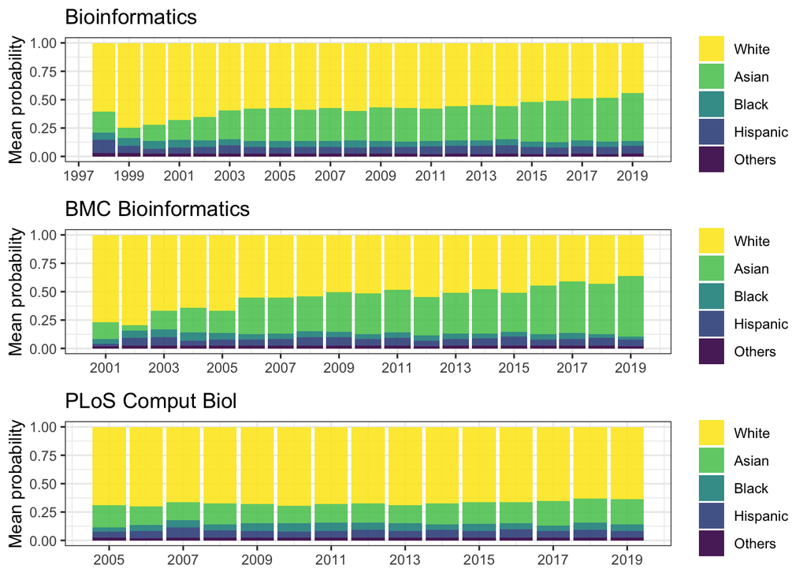

```r
plot_pubmed_race <- vector('list', length = n_jours)
i <- 0
for (jour in my_jours){
  i <- i + 1
  plot_pubmed_race[[i]] <- iscb_pubmed %>%
    filter(type == 'Pubmed' & journal == jour & (Race != 'All others')) %>%
    group_by(year, Race) %>%
    summarise(mean_prob = mean(Probabilities, na.rm = T)) %>%
    ungroup() %>%
    dynamic_contribution(jour)
}

do.call(cowplot::plot_grid, c(plot_pubmed_race, nrow = 3))
```

By conference keynotes/fellows:

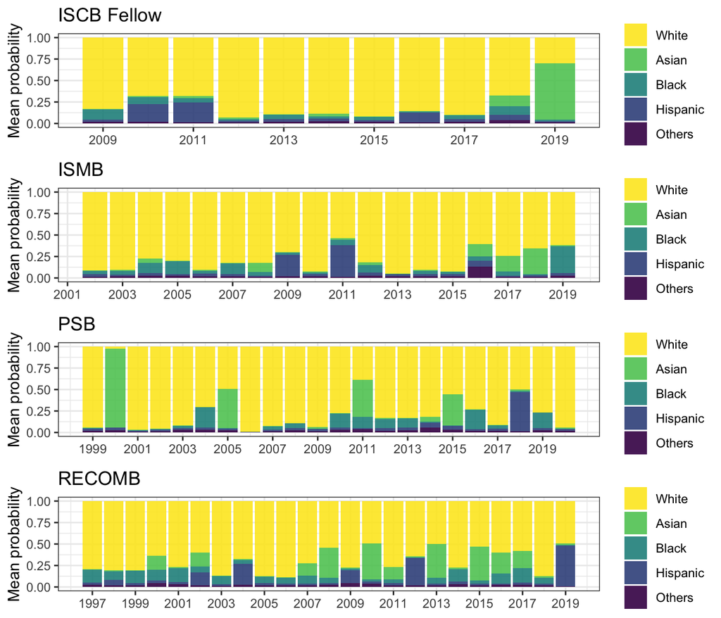

```r
i <- 0
plot_iscb_race <- vector('list', length = n_confs)

for (conf in my_confs){
  i <- i + 1
  plot_iscb_race[[i]] <- iscb_pubmed %>%
    filter(type != 'Pubmed' & journal == conf & (Race != 'All others')) %>%
    group_by(year, Race) %>%
    summarise(mean_prob = mean(Probabilities, na.rm = T)) %>%
    ungroup() %>%
    dynamic_contribution(conf)
}
do.call(cowplot::plot_grid, c(plot_iscb_race, nrow = n_confs))
```

All fellows and keynotes compared to three ISCB partner journals:

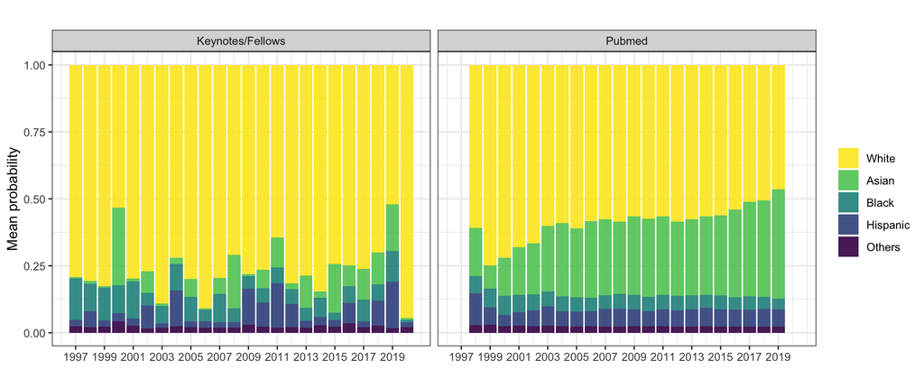

```r
iscb_pubmed %>%
  filter(Race != 'All others') %>%
  group_by(year, type, Race) %>%
  summarise(mean_prob = mean(Probabilities, na.rm = T)) %>%
  ungroup() %>%
  dynamic_contribution() +
  facet_wrap( ~ type)
```

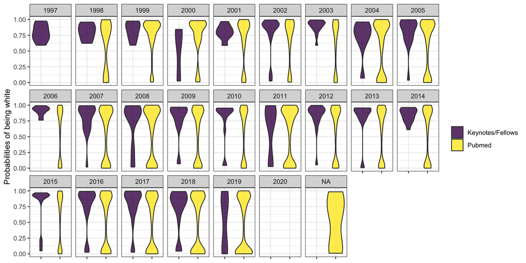

```r
# boxplot iscb, pubmed faceted by year
iscb_pubmed %>%
  filter(Race == 'White') %>%
  ggplot(aes(x = type, fill = type, y = Probabilities)) +
  geom_violin(alpha = 0.8) +
  facet_wrap(~ year(year), nrow = 3) +
  theme_bw() +
  labs(x = NULL, y = 'Probabilities of being white') +
  scale_x_discrete(label = NULL) +
  theme(legend.title = element_blank()) +
  scale_fill_viridis_d()
```

Confidence interval of the mean? (Aggregation)

Null: The proportion of white keynote iscb speakers is not larger the proportions of white last authors published in Pubmed Central. Alternative: The proportion of white keynote iscb speakers is larger the proportions of white last authors published in Pubmed Central. How do we take time component into account? Right now, I’m thinking we can use `year` as a random variable. Perhaps we should allow for random slope as well?

Bootstrap?

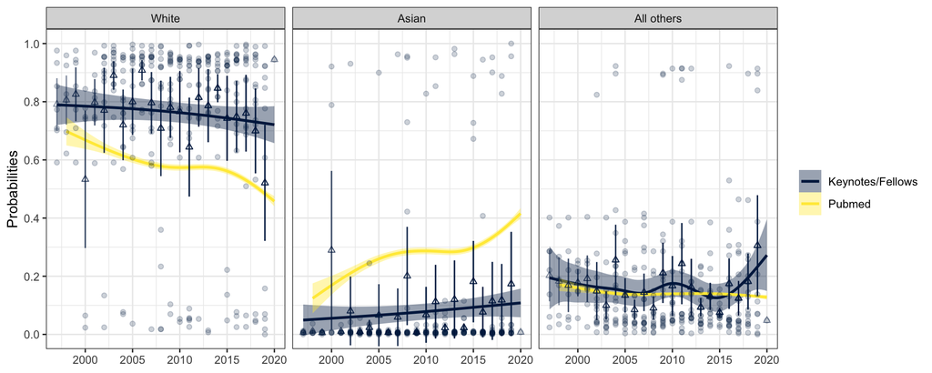

```r
get_summary <- function(df){
  df %>% filter(type != 'Pubmed') %>% select(- Probabilities) %>% distinct()
}

ggplot(iscb_pubmed %>% filter(Race == 'White' | Race == 'Asian' | Race == 'All others'),
       aes(x = year)) +
  facet_grid(cols = vars(fct_rev(Race))) +
  geom_smooth(aes(x = publication_date, y = Probabilities, color = type, fill = type)) +
  geom_point(
    data = . %>% filter(type != 'Pubmed'),
    aes(y = Probabilities, color = type),
    alpha = 0.2,
    show.legend = F
  ) +
  geom_point(
    data = . %>% get_summary(),
    aes(y = mean_prob, color = type),
    shape = 2,
    alpha = 0.5,
    show.legend = F
  ) +
  geom_linerange(
    data = . %>% get_summary(),
    aes(
      ymin = mean_prob - me_prob,
      ymax = mean_prob + me_prob,
      color = type
    ),
    alpha = 0.5,
    show.legend = F
  ) +
  theme_bw() +
  scale_y_continuous(breaks = seq(0, 1, 0.2)) +
  theme(legend.title = element_blank()) +
  scale_color_viridis_d(option = 'E') +
  scale_fill_viridis_d(option = 'E') +
  coord_cartesian(ylim = c(0, 1)) +
  labs(x = NULL)
```

```r
# Check: probabilities, if valid, should add up to 1
iscb_pubmed %>%
  filter(Race == 'White' | Race == 'Asian' | Race == 'All others') %>%
  group_by(type, year, publication_date, Race) %>%
  summarise(mean_prob = mean(Probabilities, na.rm = T)) %>%
  summarise(all_prob = sum(mean_prob))
```

```
## # A tibble: 4,506 x 4
## # Groups:   type, year [47]
##    type             year       publication_date all_prob
##    <chr>            <date>     <date>              <dbl>
##  1 Keynotes/Fellows 1997-01-01 1997-01-01              1
##  2 Keynotes/Fellows 1998-01-01 1998-01-01              1
##  3 Keynotes/Fellows 1999-01-01 1999-01-01              1
##  4 Keynotes/Fellows 2000-01-01 2000-01-01              1
##  5 Keynotes/Fellows 2001-01-01 2001-01-01              1
##  6 Keynotes/Fellows 2002-01-01 2002-01-01              1
##  7 Keynotes/Fellows 2003-01-01 2003-01-01              1
##  8 Keynotes/Fellows 2004-01-01 2004-01-01              1
##  9 Keynotes/Fellows 2005-01-01 2005-01-01              1
## 10 Keynotes/Fellows 2006-01-01 2006-01-01              1
## # … with 4,496 more rows
```